# Improving the fight against corruption

By: **StudentA**, **StudentB** and **StudentC**

This post see to uncover the relationships among a set of varisbles; in particular, it shows if the economy and press freedom are good predictors of corruption control worldwide.

The data we have used was previously organized in Python, you can see that [here](https://github.com/EvansDataScience/basicFinal_CompThink/blob/master/projectDataPreprocessing.ipynb).

Let us call the data:

```r
dataLink="https://github.com/EvansDataScience/basicFinal_CompThink/raw/master/dataProject.csv"
df=read.csv(dataLink,stringsAsFactors = FALSE)
```

These are the contents:

```r
str(df)
```

```
## 'data.frame':    153 obs. of  5 variables:
##  $ iso       : chr  "ALB" "DZA" "AGO" "ARG" ...
##  $ country   : chr  "Albania" "Algeria" "Angola" "Argentina" ...
##  $ corruption: int  39 34 18 36 33 79 75 30 43 26 ...
##  $ economy   : num  7.54 4.84 5.4 4.88 7.6 7.99 7.66 6.38 7.38 6.32 ...
##  $ press     : num  60 48.2 50 64.8 61.1 ...
```

The variable corruption behaves like this:

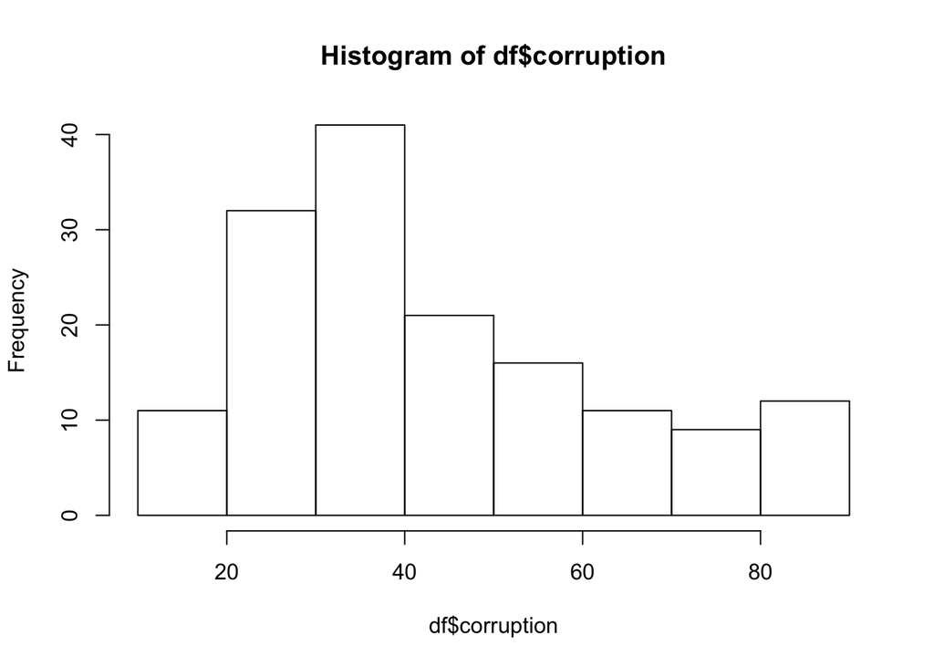

```r
hist(df$corruption)
```

Let me see how each of the proposed predictors relates to our dependent variable:

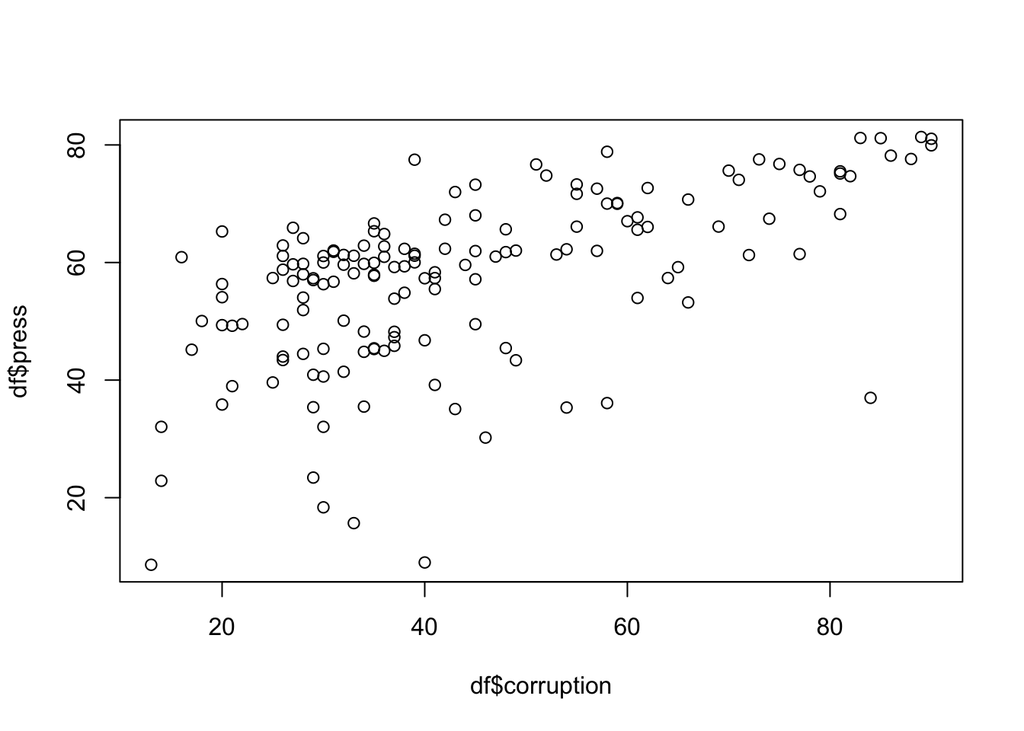

```r
plot(df$corruption,df$press)
```

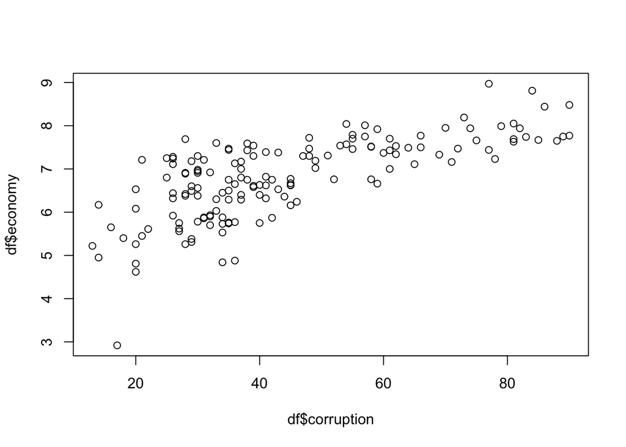

```r
plot(df$corruption,df$economy)
```

We know that the predictors have a fairly linear relationship with the dependent variable, then we can test our hypothesis by seeing the effect of each controlling by the other:

```r
test=lm(as.numeric(corruption)~press+economy,data=df)
```

The result is shown here:

```r
summary(test)
```

```
##
## Call:
## lm(formula = as.numeric(corruption) ~ press + economy, data = df)
##
## Residuals:
##      Min       1Q   Median       3Q      Max
## -25.6113  -7.2466  -0.3429   8.1577  25.2325
##
## Coefficients:
##              Estimate Std. Error t value Pr(>|t|)
## (Intercept) -61.88179    7.37537  -8.390 3.32e-14 ***
## press         0.45142    0.07453   6.057 1.07e-08 ***
## economy      11.79973    1.17397  10.051  < 2e-16 ***
## ---
## Signif. codes:  0 '***' 0.001 '**' 0.01 '*' 0.05 '.' 0.1 ' ' 1
##
## Residual standard error: 12.22 on 150 degrees of freedom
## Multiple R-squared:  0.6035, Adjusted R-squared:  0.5982
## F-statistic: 114.2 on 2 and 150 DF,  p-value: < 2.2e-16
```

As we see above, our model is **significant** with a decent Adjusted R-squared:

```r
summary(test)$adj.r.squared
```

```
## [1] 0.598232
```

Next, we need to verify some requisites so that our results are trustable.

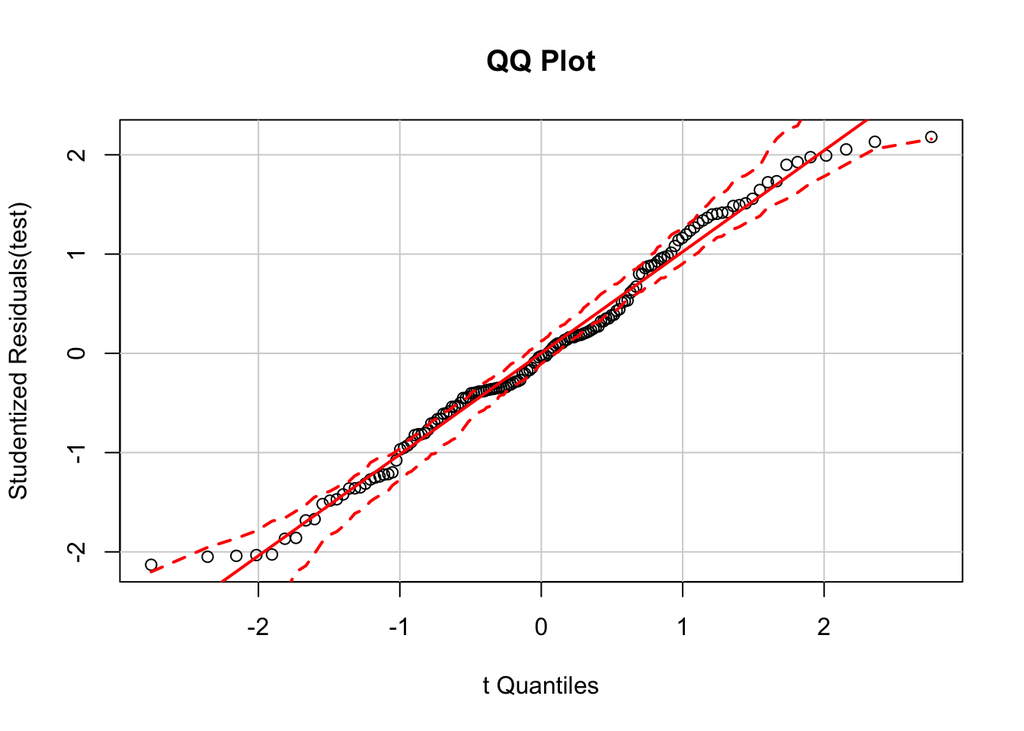

```r
# normality of residuals?
library(car)
qqPlot(test, main="QQ Plot")
```

```r
# homocedastic?
ncvTest(test)
```

```
## Non-constant Variance Score Test
## Variance formula: ~ fitted.values
## Chisquare = 4.022599    Df = 1     p = 0.04489448
```

3. The predictors are no highly correlated:

```r
# collinearity?
vif(test) > 4 # problem?
```

```
##   press economy
##   FALSE   FALSE
```

4. Detect the change if influential observations are eliminated:

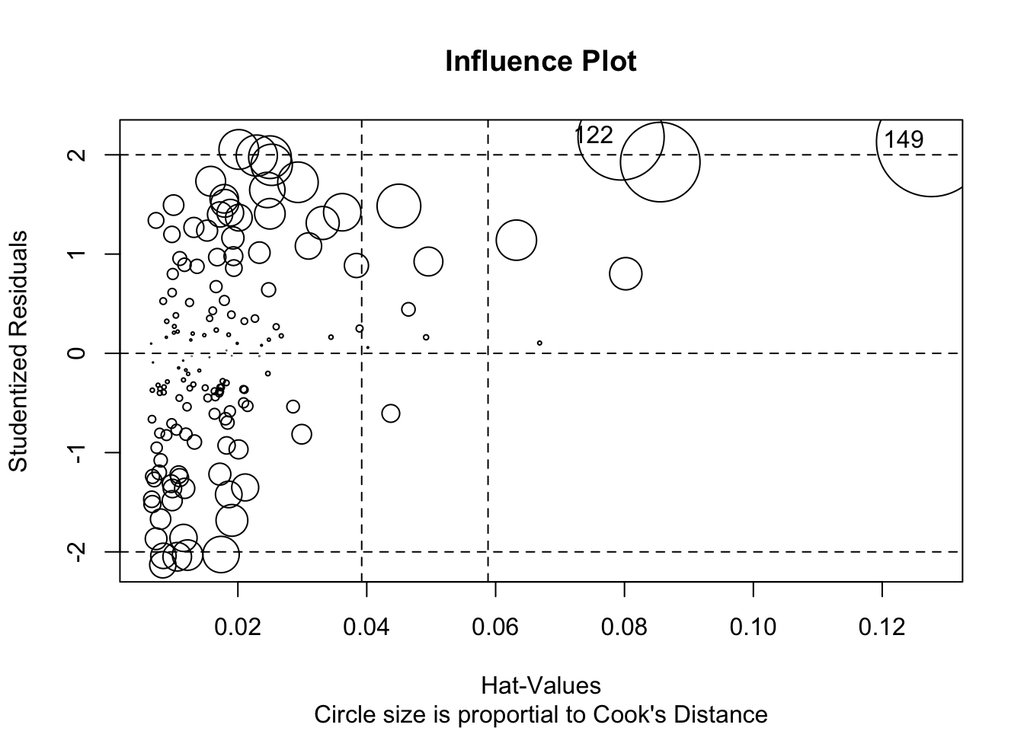

```
##      StudRes        Hat     CookD
## 122 2.179466 0.07947023 0.1333587
## 149 2.131183 0.12762379 0.2163776
```

```r
influencePlot(test, id.method = 'noteworthy', main="Influence Plot", sub="Circle size is proportial to Cook's Distance" )
```

Those cases (rows) are not considered now:

```r
CountrysOUT=c(122,149)
summary(lm(as.numeric(corruption)~press+economy,
           data=df[-CountrysOUT,]))
```

```
##
## Call:
## lm(formula = as.numeric(corruption) ~ press + economy, data = df[-CountrysOUT,
##     ])
##
## Residuals:
##     Min      1Q  Median      3Q     Max
## -25.466  -7.359  -0.288   8.089  24.572
##
## Coefficients:
##              Estimate Std. Error t value Pr(>|t|)
## (Intercept) -64.91819    7.75582  -8.370 3.99e-14 ***
## press         0.47059    0.07493   6.281 3.55e-09 ***
## economy      12.03595    1.26562   9.510  < 2e-16 ***
## ---
## Signif. codes:  0 '***' 0.001 '**' 0.01 '*' 0.05 '.' 0.1 ' ' 1
##
## Residual standard error: 11.95 on 148 degrees of freedom
## Multiple R-squared:  0.6097, Adjusted R-squared:  0.6044
## F-statistic: 115.6 on 2 and 148 DF,  p-value: < 2.2e-16
```

As you can see, this got better…

[GO BACK TO REPO](https://github.com/EvansDataScience/basicFinal_CompThink)